# DRAFT California State Water Resources Control Board’s Guide to Publishing on the California Open Data Portal

## 1 Introduction

This document describes the basics of how to publish and maintain a dataset on the [California Open Data Portal](https://data.ca.gov/) for staff at the California State Water Resources Control Board. In the context of the California Open Data Portal, a dataset is a collection of data resources (which are files or links to files containing data, such as CSV files), together with a description and other supporting information (metadata), at a fixed URL.

The instructions below demonstrate how to create a new dataset, then add one or more data resources to that dataset. If you want to manage an existing dataset (including adding a new data resource, updating an existing data resource, or editing dataset metadata), skip to the Managing an Existing Dataset or Data Resource section.

## 2 Creating a New Dataset

1. Go to https://data.ca.gov and click on the **Log in** button at the top right of the window to log in to your user account. (NOTE: if you don’t already have an account on the data.ca.gov portal, you’ll need to contact Office of Information Management and Analysis (OIMA) staff to create an account and get added to the Water Board’s organizational account.)

[figure not shown]

2. In your account dashboard, click on the **My Organizations** tab, then click on the **California State Water Resources Control Board** icon. (NOTE: you should be automatically taken to the dashboard page after logging in to your account; you can also access the dashboard page by clicking on the dashboard icon (which looks like a speed dial) in the upper right side of the data.ca.gov webpage, next to your user name.)

[figure not shown]

3. On the organization page, click on the **Add Dataset** button.

[figure not shown]

4. Fill in the dataset metadata (e.g., Title, Description, etc.). Guidance on how to populate the metadata is available [here](https://docs.data.ca.gov/california-open-data-publishers-handbook/3.-create-metadata-and-data-dictionary) and [here](https://data.ca.gov/pages/creating-metadata-and-data-dictionary).

[figure not shown]

   NOTE: Use the **Visibility** dropdown menu to control whether or not your dataset is publicly accessible. Use the **Private** option to restrict visibility of your dataset to only other users of the Water Board’s orgainzational account on the Open Data Portal (this is useful when drafting your dataset prior to publication), or use the **Public** option to make your dataset accessible to the general public.

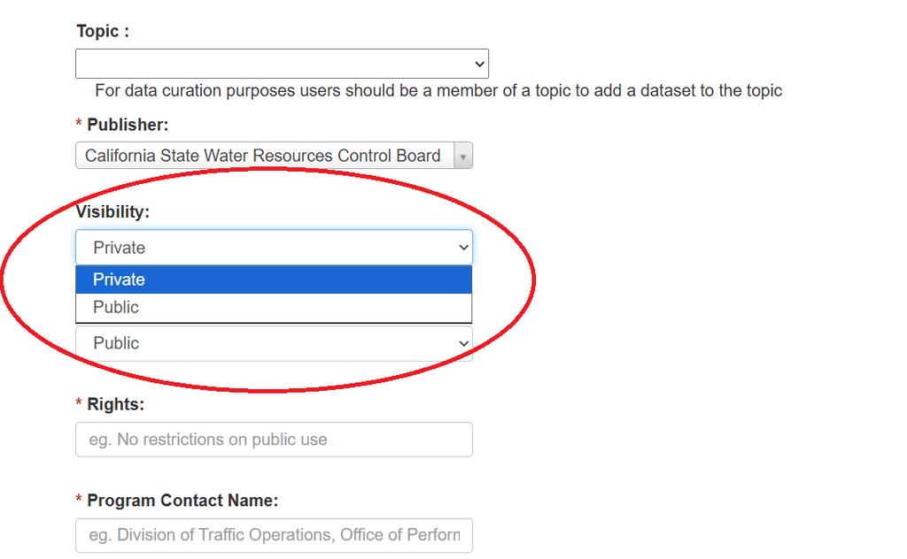

   When you’re finished, click on the **Next: Add Data** button at the bottom of the page.

[figure not shown]

5. Add a file containing your data using either the **Upload** or **Link** buttons, add a title and description for the resource, then click the **Finish** button, or click the **Save & add another** button to add another data resource. Guidance on how to format a data file for publication on the open data portal is available [here](https://docs.data.ca.gov/california-open-data-publishers-handbook/2.-prepare-data-for-publishing) and [here](https://data.ca.gov/pages/preparing-data-publication-datastore).

[figure not shown]

6. Add a data dictionary for the data resource you just created using one or both of the following methods:
   - A: Upload a PDF containing the data dictionary as a separate resouce in the dataset
   - B: Add the data dictionary directly to the data resource’s page (the data dictionary will appear below the data table)

   Guidance on how to populate the data dictionary is available [here](https://docs.data.ca.gov/california-open-data-publishers-handbook/3.-create-metadata-and-data-dictionary#create-your-data-dictionary), [here](https://data.ca.gov/pages/creating-metadata-and-data-dictionary), and [here](https://docs.google.com/document/d/1GMD9CplnCgX723ot3yOLkXVnuexZdO2X00VLInidiws/edit#heading=h.lcji112b1gb9).
   1. Upload a PDF containing the data dictionary to the dataset (as a separate resource), by going to the dataset homepage and clicking on the **Manage** button.

[figure not shown]

      Then click on the **Resources** tab, and click on the **Add new resource** button.

[figure not shown]

      Upload the PDF file by clicking the **Upload** button, then click on the **Add** button.

[figure not shown]

   2. Add the data dictionary directly to the data resource by going to the data resource’s page and clicking on the **Manage** button. (**NOTE**: After uploading a new data resource, before you can add data dictionary information you’ll need to wait until the data table appears on the resource’s page, as shown in the screenshot below; this could take a few minutes, depending on the size of the resource.)

[figure not shown]

      Go to the **Data Dictionary** tab, then fill in the available information for each field in the data resource.

[figure not shown]

      Click the **Save** button when finished.

[figure not shown]

      After saving the data dictionary information, the data dictionary will appear below the data table on the resource’s page. (**NOTE**: you may need to update the resource’s **DataStore** to make sure all of the changes to the data dictionary are applied to the resource; to do this, see the instructions in Step 2 of the *Managing an Existing Dataset or Data Resource* section below.)

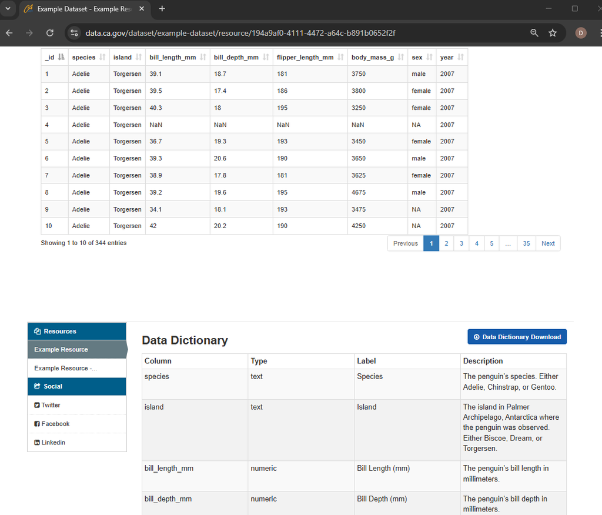

      **NOTE:** Setting the data type for each field by selecting a value in the **Type Override** box is especially useful if your users will be accessing the data via the API, but you’ll need to ensure that all of the data in the given field is compatible with that data type before setting a data type other than ‘text’. If there are problems with the data types, you can find more information by following the instructions in Step 2 of the *Managing an Existing Dataset or Data Resource* section below, and going to the **DataStore** tab.

      If you need to add data dictionary information for data resources with many fields and/or datasets with large numbers of resources, you can contact OIMA staff for assistance with automating the process of uploading that data dictionary information (to avoid the need for manual entry of the data dictionary information).

## 3 Managing an Existing Dataset or Data Resource

### 3.1 Update Dataset Metadata or Add Additional Data Resource

To add an additional data resource to an existing dataset, or to update the metadata for an existing dataset:

1. Go to the dataset and click on the **Manage** button.

[figure not shown]

2. To update the dataset’s metadata, click on the **Edit metadata** tab. To add a new data resource to the dataset click on the **Resources** tab then click on the **Add new resource** button.

[figure not shown]

If you’re adding a new data resource that doesn’t already have an associated data dictionary available on the portal, you’ll need to add a data dictionary for your resource. See Step #6 above for information on how to do this.

### 3.2 Manage Existing Data Resource

To manage an existing data resource (i.e., an existing file within a dataset and/or the file’s associated metadata):

1. Go to the data resource’s page, then click on the **Manage** button.

[figure not shown]

2. Go to the **Edit Resource** tab to update the data file or update the resource’s title or description, go to the **DataStore** tab to ensure that the data has been correctly uploaded to the database that feeds the resource’s API, or go to the **Data Dictionary** tab to add information about each field and set the fields’ data types.

[figure not shown]

## 4 Additional Resources

For more information about publishing open data resources on the California Open Data Portal, see the following resources:

- [California Open Data Publisher’s Handbook](https://docs.data.ca.gov/california-open-data-publishers-handbook)
- [California Open Data Portal Publisher’s Guide](https://data.ca.gov/pages/open-data-publisher-guide-contents)
- California State Water Board’s Open Data Publishing Guide
- [California State Water Board’s Recommendations and Guidelines for Data Dictionary Development](https://docs.google.com/document/d/1GMD9CplnCgX723ot3yOLkXVnuexZdO2X00VLInidiws/edit#heading=h.lcji112b1gb9)
- [California State Water Board’s Open Data Handbook](https://www.waterboards.ca.gov/resources/oima/cowi/open_data_handbook.html)